# MB5370 Module 2 Workshop 1

Caitlin Buckle

2026-06-02

Load required packages

Your computers activity memory can retain hidden values/old variables etc. To eliminate this issue, establish a base workflow at the top of every fresh script file, using the code below.

### Section 1.4: Ingesting Data into R

Practicing reading different kinds of data files into R

If we record notes or convserational summary lines at the top of Excel data sheets, R will treat these at your database column headers, which will corrupt your entire data ingestion pipeline.

#### EXAMPLE: using mangrove_survey_raw.csv

### Section 1.5: Data Frame Architectures: Tibble versus Legacy Tables

When you import assets using tidyverse commands, the resulting object is stored is a structure called a tibble. Whilst a tibble is still fundamentally a base R data frame, its underlying software architecture has been optimised to prevent common data corruption erros and console performance issues. Understanding how these two data structures behave differently under pressure is essential for error diagnostics.

#### EXAMPLE of behavioural difference of Base R data frame and modern tidyverse tibble

### Section 1.6: Wrangling Out Ecological Signals Using Palmer Penguins

palmerpenguins dataset contains multi-species morphological tracking records collected at Palmer Station long-term ecological research site in Antarctica.

### Section 1.7: Foundational Grammar: Slicing, Filtering, Sorting, and Transforming

#### Section 1.7.1: Isolating Attributes with select()

Ecological data frequently collect duplicate logistics records that do not contribute to morphological or physiological questions. Select() allows you to slice your data sets vertically, allowing you to isolate or drop columns based on variable names

#### EXAMPLE

```
## Rows: 344
## Columns: 4
## $ species        <fct> Adelie, Adelie, Adelie, Adelie, Adelie, Adelie, Adelie,…
## $ bill_length_mm <dbl> 39.1, 39.5, 40.3, NA, 36.7, 39.3, 38.9, 39.2, 34.1, 42.…
## $ bill_depth_mm  <dbl> 18.7, 17.4, 18.0, NA, 19.3, 20.6, 17.8, 19.6, 18.1, 20.…
## $ body_mass_g    <int> 3750, 3800, 3250, NA, 3450, 3650, 3625, 4675, 3475, 425…
```

#### Section 1.7.1: Sifting rows with filter()

filter() isolates records horizontally based on targeted conditional parameters. R evaluates every row against your logical expressions, and will retain entries that evaluate to TRUE and drop those returning FALSE or NA.

#### Section 1.7.3: Ordering sequences with arrange()

arrange() alters the sorting configuration of rows within your dataframe without changing individual cell values - essential for inspecting size hierarchies or chronologically ordering long-term environmental observations lines.

#### Section 1.7.4: Introducting the Pipe (|>)

The pipe allows us to chain operations together, meaning you can pass data through a series of transformations in a single, linear flow. Without a pipe, you have to read the code inside-out (e.g., you start in the middle, perform the mutate(), then wrap that in a filter(), and then wrap that all in a select()). With a pipe, you read from left to right, or top to bottom (e.g., you take your data, then you filter it, then you mutate it to create a new column, then you select the columns that you need).

Syntax for native R pipe is |>, although there is a pipe operator built into the tidyverse package magrittr which is very common (%>%)

#### Section 1.7.5: Computing New Attributes with mutate()

It is common in marine science/ecology to need to calculate new variables based on ones that preexist in our raw data. In data wrangling, this is called “mutating” and can be done using mutate() function.

```
## Rows: 344
## Columns: 10
## $ species           <fct> Adelie, Adelie, Adelie, Adelie, Adelie, Adelie, Adel…
## $ island            <fct> Torgersen, Torgersen, Torgersen, Torgersen, Torgerse…
## $ bill_length_mm    <dbl> 39.1, 39.5, 40.3, NA, 36.7, 39.3, 38.9, 39.2, 34.1, …
## $ bill_depth_mm     <dbl> 18.7, 17.4, 18.0, NA, 19.3, 20.6, 17.8, 19.6, 18.1, …
## $ flipper_length_mm <int> 181, 186, 195, NA, 193, 190, 181, 195, 193, 190, 186…
## $ body_mass_g       <int> 3750, 3800, 3250, NA, 3450, 3650, 3625, 4675, 3475, …
## $ sex               <fct> male, female, female, NA, female, male, female, male…
## $ year              <int> 2007, 2007, 2007, 2007, 2007, 2007, 2007, 2007, 2007…
## $ body_mass_kg      <dbl> 3.750, 3.800, 3.250, NA, 3.450, 3.650, 3.625, 4.675,…
## $ bill_ratio        <dbl> 2.090909, 2.270115, 2.238889, NA, 1.901554, 1.907767…
```

### Section 1.8: Data Aggregation and Ecological Summarisation

To extract meaningful biological conclusions (e.g., determining whether morphological allometry varies by species or island group), you must compress thousands of individual observations into explicit population summary metrics - this is achieved using the dual layered combination of group_by() and summarise().

When you apply group_by(), R does not alter the physical appearance of the table, instead it alters how it interacts with subsequent functions by creating hidden, virtual data buckets based on categorical factor levels. When you immediately follow this with summarise(), R calculates targeted statistical reductions for each individual bucket and collapses them into a brand-new summary tibble.

```
## # A tibble: 344 × 8
## # Groups:   species [3]
##    species island    bill_length_mm bill_depth_mm flipper_length_mm body_mass_g
##    <fct>   <fct>              <dbl>         <dbl>             <int>       <int>
##  1 Adelie  Torgersen           39.1          18.7               181        3750
##  2 Adelie  Torgersen           39.5          17.4               186        3800
##  3 Adelie  Torgersen           40.3          18                 195        3250
##  4 Adelie  Torgersen           NA            NA                  NA          NA
##  5 Adelie  Torgersen           36.7          19.3               193        3450
##  6 Adelie  Torgersen           39.3          20.6               190        3650
##  7 Adelie  Torgersen           38.9          17.8               181        3625
##  8 Adelie  Torgersen           39.2          19.6               195        4675
##  9 Adelie  Torgersen           34.1          18.1               193        3475
## 10 Adelie  Torgersen           42            20.2               190        4250
## # ℹ 334 more rows
## # ℹ 2 more variables: sex <fct>, year <int>
```

```
## # A tibble: 3 × 2
##   species   mean_mass_g
##   <fct>           <dbl>
## 1 Adelie            NA
## 2 Chinstrap       3733.
## 3 Gentoo            NA
```

The summary operation for Adelie and Gentoo failed and returned NA due to a behavioural design feature of R called the Missing Value trap. If a column contains even only one missing observation flag (NA), any mathematical aggregation function will automatically return NA to protect you from miscalculating metrics on incomplete data. To override this safely, you must explicitly declare that missing cells should be dropped during calculation.

This can be completed using the magrittr pipe to wrangle our data and avoid the missing value trap.

```
## # A tibble: 8 × 5
## # Groups:   species [3]
##   species   sex    sample_size mean_mass_g sd_mass_g
##   <fct>     <fct>        <int>       <dbl>     <dbl>
## 1 Adelie    female          73       3369.      269.
## 2 Adelie    male            73       4043.      347.
## 3 Adelie    <NA>             6       3540       477.
## 4 Chinstrap female          34       3527.      285.
## 5 Chinstrap male            34       3939.      362.
## 6 Gentoo    female          58       4680.      282.
## 7 Gentoo    male            61       5485.      313.
## 8 Gentoo    <NA>             5       4588.      338.
```

### Section 1.9: Integrating Data Grammer with Visual Diagnostics in Qmd

Data manipulation and visualisation are not separate tasks.

#### Section 1.9.2: Piping Directly to Visualisation

You can skip creating a summary table if it is not necessary, and extend your pipeline directly into ggplot2.

#### EXAMPLE: Visualising mean trends with uncertainty

Instead of created a summary table first, you can pipe your grouped data straight into a plot and use geom_errorbar() to represent the spread of your data

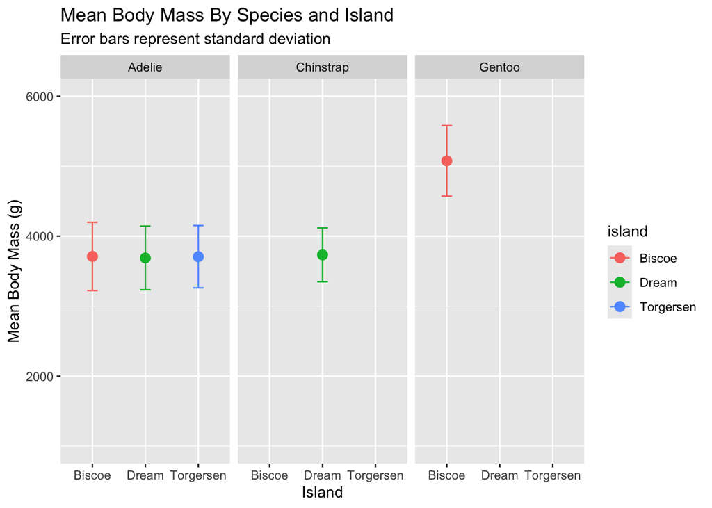

#### PAUSE FOR THOUGHT - Think about what this figure is telling you about the biology of these species of penguins on different islands. What do you think a statistical test would tell you here?

Mean mass (g) of Adelie penguins is relatively similar across all three islands, and a statistical test would struggle to find a statistically significant difference between islands for this species. Whilst it is clear that Gentoo penguins ar the heaviest of the penguin species found on these islands, we do not have data on their mean mass on Dream or Torgensen Island, so unable to make any comments regarding biological differences within a species based on island location. The same is the case for Chinstrap penguns (although this time we only have data for Dream Island), and we can also see that the mean body mass is relatively similar for Adelie and Chinstrap penguins.

#### CHALLENGE - swap standard deviation for standard error and see how it changes the visual interpretation of your data

[figure not shown]

Errors bars are now considerably smaller than when viewing the standard deviation error bars. This is because the standard error is a measure of how much the sample mean (mean_mass) is expected to vary from the true population mean, and it decreases as the sample size (n) increases. In contrast, the standard deviation (sd_mass) measures the variability of individual data points around the sample mean, regardless of sample size. Therefore, when we switch from standard deviation to standard error, we are accounting for the sample size in our error bars, which results in smaller error bars.

### Section 1.10: Saving, Exporting, and Version Milestones

In the future, you may encounter wrangling and analysis that takes signficant processing power and memory, meaning we may want to save them to our outputs. Before we do this, we need to check if we have the correct folders, and if not we can create them (see workbook for code).

Already exists in my directory : )

#### EXAMPLE: Saving Tables (as a CSV or RDS object)

#### EXAMPLE: Figures

ggplot2 has an inbuilt function to save figures - ggsave()